# Homework 8

# 3.

```r
nSim <- 100
alp <- 0.05
nVec <- c(10, 50, 100, 200)
pVec <- c(0.01, 0.1, 0.5)

### Experiment with different n
outQ3 <- map(nVec, function(n) {
  ### Experiment with different p
  map(pVec, function(p){
    ### X ~ Bin (n, p)
    X <- rbinom(n = nSim, size = n, prob = p)
    ### T
    T <- sqrt(n) * ((X / n) - p)

    ### KS test
    ### Ignore the warnings here
    ks <- ks.test(T, pnorm, mean = 0, sd = sqrt(p * (1 - p)))
    ### Compare p-value with alpha
    ### If TRUE, reject the null hypothesis that two distributions equal
    ks$p.value <= alp
  })
})

### Combine as a matrix
outQ3 <- do.call(rbind, outQ3)
dimnames(outQ3) <- list(str_c("size = ", nVec), str_c("prob = ", pVec))
outQ3
```

```
           prob = 0.01 prob = 0.1 prob = 0.5
size = 10  TRUE        TRUE       TRUE
size = 50  TRUE        TRUE       FALSE
size = 100 TRUE        TRUE       FALSE
size = 200 TRUE        FALSE      TRUE
```

The conclusion would be made accordingly, that is, if we have `TRUE`, we have sufficient evidence to reject the null and conclude that two distributions are different, otherwise, we do not have sufficient evidence to reject the null and conclude that it is plausible that two distributions are the same.

# 4. (Optional)

**(Not graded)**

```r
nSim <- 100
n <- 8000
side <- 10000
alp <- 0.05

### Repeat the experiment
EVec <- map_dbl(seq_len(nSim), function(iSim) {
  ### Generate data from the square
  X <- matrix(runif(2 * n, min = 0, max = side), ncol = 2)
  colnames(X) <- c("x", "y")

  ### Compute different combinations of distances
  dis <- dist(X)

  ### Compute D, the minimum distance
  D <- min(dis)

  ### Compute E
  E <- 1 - exp(-D^2 / 0.995)

  E
})

### Compare p-value with alpha
### If TRUE, reject the null hypothesis that two distributions equal
ks.test(EVec, punif)$p.value <= alp
```

```
[1] FALSE
```

FALSE here means we do NOT have sufficient evidence to reject the null hypothesis that two distributions equal, which means $E$ is plausible to be uniform on $[0, 1]$.

# 5.

**(Not graded)**

## a.

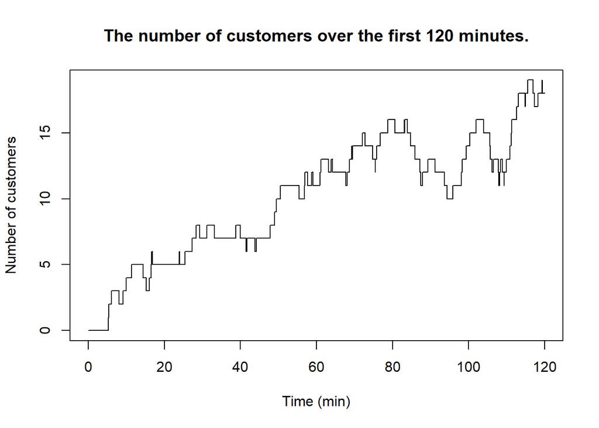

```r
n <- 200
lam1 <- 1/2
lam2 <- 1/30
T <- seq(0, 120, length.out = 10000)

### Simulate the waiting time
tW <- rexp(n, rate = lam1)

### Simulate the time spent
tS <- rexp(n, rate = lam2)

### Compute the arrival time
tA <- cumsum(tW)

### Compute the departure time
tD <- tA + tS

### Over the first 120 minutes
nC <- map_dbl(T, function(t){
  ### Number of customer in the restaurant
  sum((tA < t) & (tD > t))
})

### Plot the number of customers in the restaurant over the first 120 minutes after the restaurant opens
plot(T, nC, type = "l", xlab = "Time (min)", ylab = "Number of customers", main = "The number of customers over the first 120 minutes.")
```

## b.

```r
nSim <- 1000
TQ5bi <- c(10, 20, 30, 120)
nQ5bii <- 10
TQ5bii <- 60
nQ5biii <- 20
TQ5biii <- 60

outQ5b <- map(seq_len(nSim), function(iSim) {
  ### Simulate the waiting time
  tW <- rexp(n, rate = lam1)

  ### Simulate the time spent
  tS <- rexp(n, rate = lam2)

  ### Compute the arrival time
  tA <- cumsum(tW)

  ### Compute the departure time
  tD <- tA + tS

  ### Q5bi
  nQ5bi <- map_dbl(TQ5bi, function(t) {
    ### Number of customer in the restaurant
    sum((tA < t) & (tD > t))
  })

  ### Q5bii
  ### Indicator, TRUE if the condition in the question is satisfied
  IQ5bii <- (sum((tA < TQ5bii) & (tD > TQ5bii))) < nQ5bii

  ### Q5biii
  ### Indicator, TRUE if the condition in the question is satisfied
  IQ5biii <- (sum((tA < TQ5biii) & (tD > TQ5biii))) > nQ5biii

  list(nQ5bi = nQ5bi, IQ5bii = IQ5bii, IQ5biii = IQ5biii)
})
```

### i.

```r
### Compute the average number
colMeans(do.call(rbind, map(outQ5b, `[[`, "nQ5bi")))
```

```
[1]  4.286  7.429  9.644 14.848
```

### ii.

```r
### Compute the proportion
sum(map_lgl(outQ5b, `[[`, "IQ5bii")) / nSim
```

```
[1] 0.15
```

### iii.

```r
### Compute the proportion
sum(map_lgl(outQ5b, `[[`, "IQ5biii")) / nSim
```

```
[1] 0.021
```